# Chapter 07: Analysis of Function: Sentence Modes and Nuclear Contours without a Register Tier

It is clear that there is little relationship between the pitch accent and mode when the register tier is discounted. However, looking at the raw data for the phrase-level phonology, it looks like L% boundaries are more commonly associated with questions than declaratives.

Therefore, it might be worth looking at the nuclear contour as a whole in this data set.

## Nuclear nuclear contour

### Nuclear nuclear contour by Speaker

Distibution by speaker of nuclear nuclear contours in M-corpus (adjusted)

[output not shown]

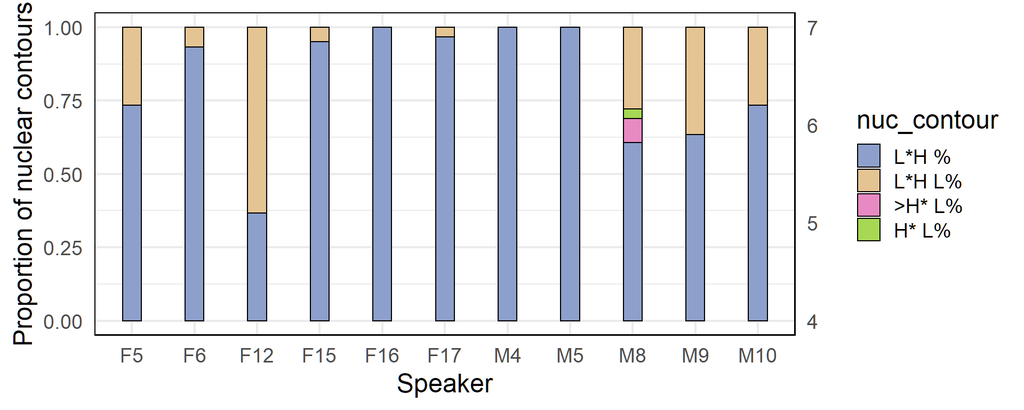

### Nuclear nuclear contour by Sentence Mode

Distibution by mode of nuclear nuclear contours in M-corpus (adjusted)

| mode | L*H % | L*H L% | >H* L% | H* L% |
| --- | --- | --- | --- | --- |
| MDC | 144 | 18 | 2 | 2 |
| MWH | 148 | 17 | 0 | 0 |
| MYN | 132 | 30 | 2 | 0 |
| MDQ | 111 | 53 | 1 | 0 |
| Total | 535 | 118 | 5 | 2 |

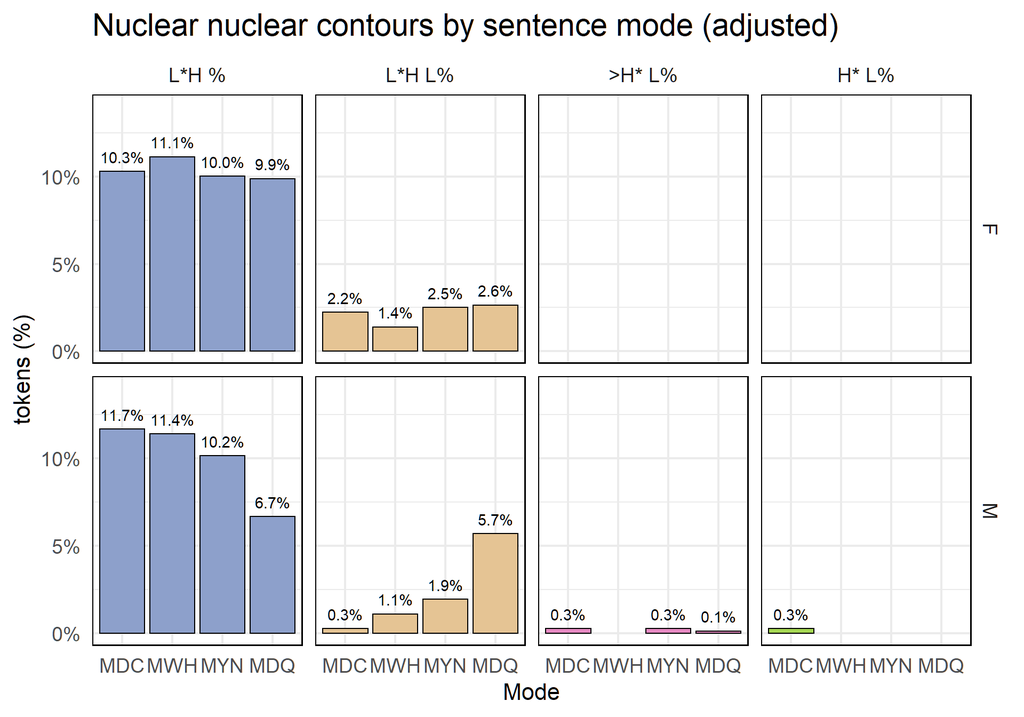

It appears that the male speakers are more likely to begin using L% across the question mode hierarchy more than the female speakers. There are not enough speakers, I believe, however, to justify this as a general conclusion, especially as it is only M8, M9, and M10 who do this.

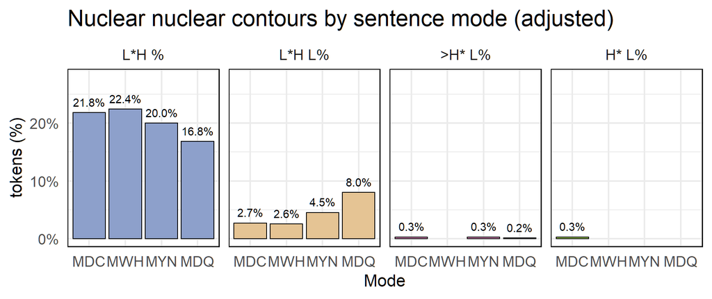

#### Chi Squared test of association using adjusted data

```
##
##  Pearson's Chi-squared test
##
## data:  .
## X-squared = 42.837, df = 9, p-value = 2.309e-06
```

The overall pattern suggest that L% is more common among YNQs and and DCQs. However, I don’t think that the L% is used to signal a question. I think that, as with the A&H corpus, L% is used when the speaker indicates there is a conflict of expectation of shared knowledge between the speaker and listener. Thus in questions like “You live in the valley?” and “Do you live in the valley?”, speaker can use the L% to indicate that the propositional content conflicts with what he or she had previously believed; i.e., it indicates surprise. In a reciprocal manner, in the declaratives of the A&H corpus (and here), the use of an L% indicates that the speaker is indicating surprise that the listener does not already share the knowledge. (i.e. “Where do you live?…”I live in the valley [L%] (and I assumed you already knew that / and you should know that already.”) … Perhaps the best way to think of this is as the surprise~redundancy strategy, with the conflict of expectations expressing redundancy in the declaratives (“This should not be news to you.”) and surprise in the questions (“I did not know this at all!”).

Bearing in mind that the >H* L% and H* L% contours all belong to M8 and may represent transitional code switching, we can re produce the chi squared test without those contours.

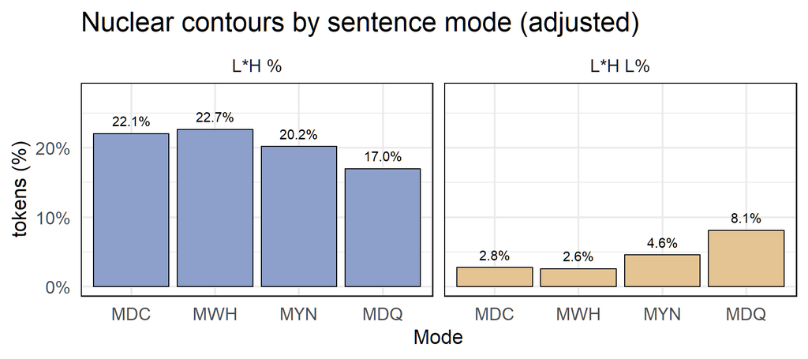

#### Chi Squared test of association using adjusted data for L*H % and L*H L% only.

```
##
##  Pearson's Chi-squared test
##
## data:  .
## X-squared = 34.529, df = 3, p-value = 1.532e-07
```

However, if we run this again, using only the female data…

```
##
##  Pearson's Chi-squared test
##
## data:  .
## X-squared = 3.7518, df = 3, p-value = 0.2895
```

… compared with the male data…

```
##
##  Pearson's Chi-squared test
##
## data:  .
## X-squared = 65.723, df = 3, p-value = 3.513e-14
```

The results give the impression that this is a feature of male rather than female speech. However, only three out of the five male speakers do this, so it is unlikely to be a features of “male speech”. More likely, different speakers interpreted the motivation behind the prompt statement and their response, in terms of the intonational phonology, reflects whether or not they chose to use a surprise/redundancy falling boundary.